# Pertemuan 2 - Regresi

Akmal Basis Jatining Kusumah

## Pemanggilan *Packages*

```r
library(dplyr)
library(TTR)
library(forecast)
library(lmtest) #digunakan untuk uji formal pendeteksian autokorelasi
library(orcutt) #untuk membuat model regresi Cochrane-Orcutt
library(HoRM) #untuk membuat model regresi Hildreth-Lu
```

## Input Data

```r
data <- read.csv("https://raw.githubusercontent.com/akmalbasisjkusumah/MPDW/main/Pertemuan%202/NewDelhi_Air_quality.csv")
data <- data[,-c(1,4,10,11)]
data
```

```
##     AQI       CO        no2       o3      pm10     pm25       so2         ts
## 1  30.2 198.6027 0.04685717 55.78995 10.486722 5.637410 0.3874302 1666375200
## 2  28.2 197.6013 0.04645554 54.93164 10.719325 4.618169 0.4097819 1666378800
## 3  26.6 198.6027 0.04685717 54.64554 11.155578 3.520902 0.4023313 1666382400
## 4  25.0 201.9405 0.04819594 55.07469 11.116206 2.225919 0.3762543 1666386000
## 5  26.0 205.2784 0.04886533 55.78995 10.405250 1.979471 0.3390014 1666389600
## 6  26.0 208.6163 0.05020411 56.50520  9.402518 1.792677 0.3129244 1666393200
## 7  26.0 208.6163 0.05020411 55.78995  8.482822 1.752237 0.3129244 1666396800
## 8  24.0 205.2784 0.05020411 52.92892  7.586667 1.858459 0.3427267 1666400400
## 9  23.0 200.2716 0.04685717 50.06790  7.636587 2.208076 0.3948808 1666404000
## 10 24.0 196.9338 0.04417961 51.49841  8.487648 2.476681 0.4284084 1666407600
## 11 25.0 198.6027 0.04284084 53.64418  9.357371 2.585729 0.4284084 1666411200
## 12 26.0 200.2716 0.04049798 55.78995 10.338728 2.390081 0.3986061 1666414800
## 13 27.0 203.6095 0.04016329 59.36623 10.523314 2.086022 0.3501773 1666418400
## 14 29.0 205.2784 0.03882451 62.22725 10.635970 1.937047 0.3166497 1666422000
```

[output cut: 58 more lines]

```r
cor(data[,-c(1,4,10,11)])
```

```
##               CO        no2        pm10       pm25         so2          ts
## CO    1.00000000  0.6520228 -0.09598578 -0.5829151 -0.79872002 -0.62078757
## no2   0.65202279  1.0000000  0.25652368 -0.3588091 -0.58591304 -0.47109406
## pm10 -0.09598578  0.2565237  1.00000000  0.2684827 -0.04779446 -0.01967075
## pm25 -0.58291511 -0.3588091  0.26848271  1.0000000  0.67434283  0.16599284
## so2  -0.79872002 -0.5859130 -0.04779446  0.6743428  1.00000000  0.50412173
## ts   -0.62078757 -0.4710941 -0.01967075  0.1659928  0.50412173  1.00000000
```

```r
Y <- data$AQI
X1 <- data$CO
X2 <- data$no2
X3 <- data$o3
X4 <- data$pm25
X5 <- data$so2

dt <- cbind.data.frame(Y, X1, X2, X3, X4, X5)
dt
```

```
##       Y       X1         X2       X3       X4        X5
## 1  30.2 198.6027 0.04685717 55.78995 5.637410 0.3874302
## 2  28.2 197.6013 0.04645554 54.93164 4.618169 0.4097819
## 3  26.6 198.6027 0.04685717 54.64554 3.520902 0.4023313
## 4  25.0 201.9405 0.04819594 55.07469 2.225919 0.3762543
## 5  26.0 205.2784 0.04886533 55.78995 1.979471 0.3390014
## 6  26.0 208.6163 0.05020411 56.50520 1.792677 0.3129244
## 7  26.0 208.6163 0.05020411 55.78995 1.752237 0.3129244
## 8  24.0 205.2784 0.05020411 52.92892 1.858459 0.3427267
## 9  23.0 200.2716 0.04685717 50.06790 2.208076 0.3948808
## 10 24.0 196.9338 0.04417961 51.49841 2.476681 0.4284084
## 11 25.0 198.6027 0.04284084 53.64418 2.585729 0.4284084
## 12 26.0 200.2716 0.04049798 55.78995 2.390081 0.3986061
## 13 27.0 203.6095 0.04016329 59.36623 2.086022 0.3501773
## 14 29.0 205.2784 0.03882451 62.22725 1.937047 0.3166497
```

[output cut: 58 more lines]

## Eksplorasi Data

Sebelum melakukan regresi, akan diperlihatkan *plot time-series* dari nilai Y pada data

```r
#Membentuk objek time series
data.ts<-ts(dt)
data.ts
```

```
## Time Series:
## Start = 1
## End = 72
## Frequency = 1
##       Y       X1         X2       X3       X4        X5
##  1 30.2 198.6027 0.04685717 55.78995 5.637410 0.3874302
##  2 28.2 197.6013 0.04645554 54.93164 4.618169 0.4097819
##  3 26.6 198.6027 0.04685717 54.64554 3.520902 0.4023313
##  4 25.0 201.9405 0.04819594 55.07469 2.225919 0.3762543
##  5 26.0 205.2784 0.04886533 55.78995 1.979471 0.3390014
##  6 26.0 208.6163 0.05020411 56.50520 1.792677 0.3129244
##  7 26.0 208.6163 0.05020411 55.78995 1.752237 0.3129244
##  8 24.0 205.2784 0.05020411 52.92892 1.858459 0.3427267
##  9 23.0 200.2716 0.04685717 50.06790 2.208076 0.3948808
## 10 24.0 196.9338 0.04417961 51.49841 2.476681 0.4284084
```

[output cut: 62 more lines]

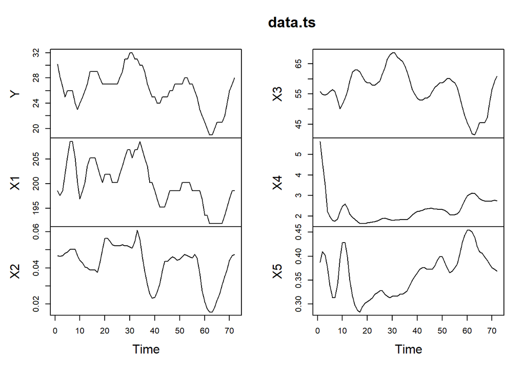

```r
#Membuat plot time series
plot.ts(data.ts)
points(data.ts)
```

```r
dev.copy(png, "Plot Time Series.png")
```

```r
dev.off()
```

Eksplorasi pertama yang dilakukan adalah dengan menggunakan *scatter plot*.

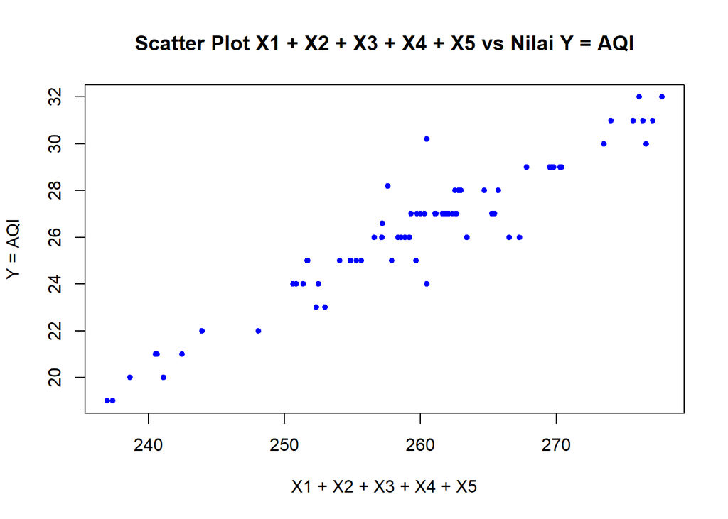

```r
#Eksplorasi Data
#Pembuatan Scatter Plot
plot(X1+X2+X3+X4+X5,Y, pch = 20, col = "blue",
     main = "Scatter Plot X1 + X2 + X3 + X4 + X5 vs Nilai Y = AQI",
     xlab = "X1 + X2 + X3 + X4 + X5",
     ylab = "Y = AQI")
```

```r
#Menampilkan Nilai Korelasi
cor(X1+X2+X3+X4+X5,Y)
```

```
## [1] 0.9520111
```

```r
dev.copy(png, "Scatter Plot.png")
```

```r
dev.off()
```

Setalah mengetahui adanya hubungan antar dua peubah, maka model regresi dapat ditentukan.

## Regresi

```r
#Pembuatan Model Regresi
#model regresi
model<- forecast::tslm(Y~X1+X2+X3+X4+X5, data = data.ts)
summary(model)
```

```
##
## Call:
## forecast::tslm(formula = Y ~ X1 + X2 + X3 + X4 + X5, data = data.ts)
##
## Residuals:
##      Min       1Q   Median       3Q      Max
## -1.00865 -0.19031  0.05126  0.24060  0.48683
##
## Coefficients:
##             Estimate Std. Error t value Pr(>|t|)
## (Intercept) -5.98852    3.47797  -1.722   0.0898 .
## X1           0.02813    0.01721   1.634   0.1070
## X2           9.37637    5.24174   1.789   0.0782 .
## X3           0.45991    0.01284  35.820  < 2e-16 ***
## X4           1.25523    0.08068  15.558  < 2e-16 ***
## X5          -7.57517    1.71003  -4.430 3.63e-05 ***
## ---
## Signif. codes:  0 '***' 0.001 '**' 0.01 '*' 0.05 '.' 0.1 ' ' 1
##
## Residual standard error: 0.3258 on 66 degrees of freedom
## Multiple R-squared:  0.9894, Adjusted R-squared:  0.9886
## F-statistic:  1235 on 5 and 66 DF,  p-value: < 2.2e-16
```

```r
#sisaan dan fitted value
sisaan<- model$residuals
fitValue<- model$fitted.values

#Diagnostik dengan eksploratif
par(mfrow = c(2,2))
qqnorm(sisaan)
qqline(sisaan, col = "steelblue", lwd = 2)
dev.copy(png, "Plot Asumsi Kenormalan Sisaan.png")
```

```r
dev.off()
```

```r
plot(fitValue, sisaan, col = "steelblue", pch = 20, xlab = "Sisaan", ylab = "Fitted Values", main = "Sisaan vs Fitted Values")
abline(a = 0, b = 0, lwd = 2)
dev.copy(png, "Plot Sisaan vs Fitted Values.png")
```

```r
dev.off()
```

```r
hist(sisaan, col = "steelblue")
dev.copy(png, "Histogram.png")
```

```r
dev.off()
```

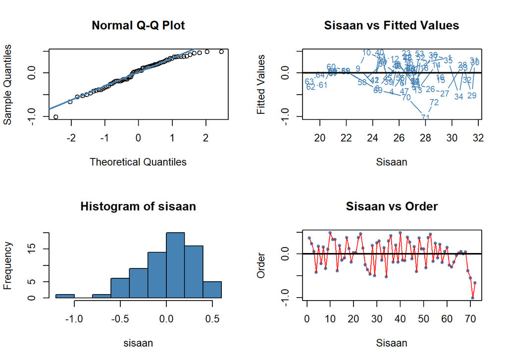

```r
plot(seq(1,72,1), sisaan, col = "steelblue", pch = 20, xlab = "Sisaan", ylab = "Order", main = "Sisaan vs Order")
lines(seq(1,72,1), sisaan, col = "red")
abline(a = 0, b = 0, lwd = 2)
```

```r
dev.copy(png, "Plot Sisaan vs Order.png")
```

```r
dev.off()
```

Dua plot di samping kiri digunakan untuk melihat apakah sisaan menyebar normal. Normal Q-Q Plot di atas menunjukkan bahwa sisaan cenderung menyebar normal, tetapi histogram dari sisaan tidak menunjukkan demikian. Selanjutnya, dua plot di samping kanan digunakan untuk melihat autokorelasi. Plot Sisaan vs *Fitted Value* dan Plot Sisaan vs *Order* menunjukkan adanya pola pada sisaan. Untuk lebih lanjut akan digunakan uji formal melihat normalitas sisaan dan plot ACF dan PACF untuk melihat apakah ada autokorelasi atau tidak.

```r
#Melihat Sisaan Menyebar Normal/Tidak
#H0: sisaan mengikuti sebaran normal
#H1: sisaan tidak mengikuti sebaran normal
shapiro.test(sisaan)
```

```
##
##  Shapiro-Wilk normality test
##
## data:  sisaan
## W = 0.96301, p-value = 0.03273
```

```r
ks.test(sisaan, "pnorm", mean=mean(sisaan), sd=sd(sisaan))
```

```
##
##  Exact one-sample Kolmogorov-Smirnov test
##
## data:  sisaan
## D = 0.092866, p-value = 0.5331
## alternative hypothesis: two-sided
```

Berdasarkan uji formal Kolmogorov-Smirnov didapatkan nilai *p-value* > $\alpha$ (5%). Artinya, cukup bukti untuk menyatakan sisaan berdistribusi normal.

```r
#ACF dan PACF identifikasi autokorelasi
par(mfrow = c(1,2))
acf(sisaan)
dev.copy(png, "Grafik ACF.png")
```

```r
dev.off()
```

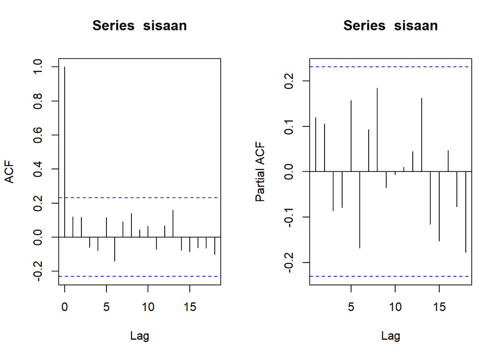

```r
pacf(sisaan)
```

```r
dev.copy(png, "Grafik PACF.png")
```

```r
dev.off()
```

Berdasarkan plot ACF dan PACF, terlihat semua dalam rentang batas dan tidak ada yang signifikan. Namun, untuk lebih memastikan akan dilakukan uji formal dengan uji Durbin Watson.

```r
#Deteksi autokorelasi dengan uji-Durbin Watson
#H0: tidak ada autokorelasi
#H1: ada autokorelasi
dwtest(model)
```

```
##
##  Durbin-Watson test
##
## data:  model
## DW = 1.6803, p-value = 0.02539
## alternative hypothesis: true autocorrelation is greater than 0
```

Berdasarkan hasil DW Test, didapatkan nilai $DW = 1.6803$ dan *p-value* = $0.02539$. Berdasarkan tabel Durbin-Watson diperoleh nilai $DL = 1.4685$ dan $DU = 1.7688$. Nilai DW masih berada di antara nilai DL dan DU. Artinya, berada di daerah inkonklusif, tidak dapat dikatakan berada di daerah autokorelasi positif maupun bebas dari autokorelasi. Namun, dengan nilai *p-value* < 0.05 dapat disimpulkan bahwa tolak H0, cukup bukti mengatakan adanya autokorelasi. Oleh karena itu, diperlukan penangan autokorelasi. Penanganan yang akan digunakan menggunakan dua metode, yaitu Cochrane-Orcutt dan Hildret-Lu.

## Penanganan Autokorelasi

### Metode Cochrane-Orcutt

Penanganan metode Cochrane-Orcutt dapat dilakukan dengan bantuan packages Orcutt pada aplikasi `R` maupun secara manual. Berikut ini ditampilkan cara menggunakan bantuan `library` *packages* `Orcutt`.

```r
#Penanganan Autokorelasi Cochrane-Orcutt
modelCO<-cochrane.orcutt(model[])
modelCO
```

```
## Cochrane-orcutt estimation for first order autocorrelation
##
## Call:
## forecast::tslm(formula = Y ~ X1 + X2 + X3 + X4 + X5, data = data.ts)
##
##  number of interaction: 11
##  rho 0.147689
##
## Durbin-Watson statistic
## (original):    1.68029 , p-value: 2.539e-02
## (transformed): 2.13850 , p-value: 5.042e-01
##
##  coefficients:
## (Intercept)          X1          X2          X3          X4          X5
##   -4.224160    0.018503    8.227037    0.462981    1.024578   -6.070250
```

Hasil keluaran model setelah dilakukan penanganan adalah sebagai berikut.
$$y_{it}=-4.224160+0.018503x_{1t}+8.227037_{2t}+0.462981_{3t}+1.024578_{4t}-6.070250_{5t}$$
Hasil juga menunjukkan bahwa nilai DW dan p-value meningkat menjadi $2.13850$ dan $0.5042$. Nilai DW sudah berada pada rentang $DU < DW < 4-DU$ atau $1.7688 < DW < 2.2312$. Hal tersebut juga didukung dengan nilai $p-value > 0.05$, artinya belum cukup bukti menyatakan bahwa sisaan terdapat autokorelasi pada taraf nyata 5%. Untuk nilai $ρ ̂$ optimum yang digunakan adalah $0.147689$. Nilai tersebut dapat diketahui dengan *syntax* berikut.

```r
#Rho optimum
rho<- modelCO$rho
rho
```

```
## [1] 0.1476895
```

Selanjutnya akan dilakukan transformasi secara manual dengan syntax berikut ini.

```r
#Transformasi Manual
Y.trans<- Y[-1]-Y[-72]*rho
X1.trans<- X1[-1]-X1[-72]*rho
X2.trans<- X2[-1]-X2[-72]*rho
X3.trans<- X3[-1]-X3[-72]*rho
X4.trans<- X4[-1]-X4[-72]*rho
X5.trans<- X5[-1]-X5[-72]*rho
modelCOmanual<- lm(Y.trans~X1.trans+X2.trans+X3.trans+X4.trans+X5.trans)
summary(modelCOmanual)
```

```
##
## Call:
## lm(formula = Y.trans ~ X1.trans + X2.trans + X3.trans + X4.trans +
##     X5.trans)
##
## Residuals:
##      Min       1Q   Median       3Q      Max
## -0.83902 -0.25457  0.03448  0.25319  0.54531
##
## Coefficients:
##             Estimate Std. Error t value Pr(>|t|)
## (Intercept) -3.60030    3.34238  -1.077   0.2854
## X1.trans     0.01850    0.01939   0.954   0.3436
## X2.trans     8.22704    5.88076   1.399   0.1666
## X3.trans     0.46298    0.01434  32.277  < 2e-16 ***
## X4.trans     1.02458    0.15577   6.578 9.61e-09 ***
## X5.trans    -6.07025    2.12271  -2.860   0.0057 **
## ---
## Signif. codes:  0 '***' 0.001 '**' 0.01 '*' 0.05 '.' 0.1 ' ' 1
##
## Residual standard error: 0.3171 on 65 degrees of freedom
## Multiple R-squared:  0.9863, Adjusted R-squared:  0.9853
## F-statistic: 937.7 on 5 and 65 DF,  p-value: < 2.2e-16
```

```r
#Mencari Penduga Koefisien Regresi setelah Transformasi ke Persamaan Awal
b0bintang <- modelCOmanual$coefficients[1]
b0 <- b0bintang/(1-rho)
b1 <- modelCOmanual$coefficients[2]
b2 <- modelCOmanual$coefficients[3]
b3 <- modelCOmanual$coefficients[4]
b4 <- modelCOmanual$coefficients[5]
b5 <- modelCOmanual$coefficients[6]
b0
```

```
## (Intercept)
##    -4.22416
```

```r
b1
```

```
##   X1.trans
## 0.01850297
```

```r
b2
```

```
## X2.trans
## 8.227037
```

```r
b3
```

```
## X3.trans
## 0.462981
```

```r
b4
```

```
## X4.trans
## 1.024578
```

```r
b5
```

```
## X5.trans
## -6.07025
```

Hasil perhitungan koefisien regresi tersebut akan menghasilkan hasil yang sama dengan model yang dihasilkan menggunakan *packages*.

### Metode Hildreth-Lu

Penanganan kedua adalah menggunakan metode Hildreth-Lu. Metode ini akan mencari nilai SSE terkecil dan dapat dicari secara manual maupun menggunakan packages. Jika menggunakan packages, gunakan `library` *packages* `HORM`.

```r
#Penanganan Autokorelasi Hildreth lu
# Hildreth-Lu
hildreth.lu.func<- function(r, model){
  x1 <- model.matrix(model)[,2]
  x2 <- model.matrix(model)[,3]
  x3 <- model.matrix(model)[,4]
  x4 <- model.matrix(model)[,5]
  x5 <- model.matrix(model)[,6]
  y <- model.response(model.frame(model))
  n <- length(y)
  t <- 2:n
  y <- y[t]-r*y[t-1]
  x1 <- x1[t]-r*x1[t-1]
  x2 <- x2[t]-r*x2[t-1]
  x3 <- x3[t]-r*x3[t-1]
  x4 <- x4[t]-r*x4[t-1]
  x5 <- x5[t]-r*x5[t-1]

  return(lm(y~x1+x2+x3+x4+x5))
}

#Pencariab rho yang meminimumkan SSE
r <- c(seq(0.1,0.9, by= 0.1))
tab <- data.frame("rho" = r, "SSE" = sapply(r, function(i){deviance(hildreth.lu.func(i, model[]))}))
round(tab, 4)
```

```
##   rho    SSE
## 1 0.1 6.5505
## 2 0.2 6.5532
## 3 0.3 6.6750
## 4 0.4 6.9165
## 5 0.5 7.2891
## 6 0.6 7.7976
## 7 0.7 8.3710
## 8 0.8 8.9575
## 9 0.9 9.6240
```

Pertama-tama akan dicari di mana kira-kira $ρ$ yang menghasilkan SSE minimum. Pada hasil di atas terlihat $ρ$ minimum ketika 0.1. Namun, hasil tersebut masih kurang teliti sehingga akan dicari kembali $ρ$ yang lebih optimum dengan ketelitian yang lebih. Jika sebelumnya jarak antar $ρ$ yang dicari adalah 0.1, kali ini jarak antar $ρ$ adalah 0.001 dan dilakukan pada selang 0.010 sampai dengan 0.200.

```r
#Rho optimal di sekitar 0.4
rOpt <- seq(0.01,0.2, by= 0.001)
tabOpt <- data.frame("rho" = rOpt, "SSE" = sapply(rOpt, function(i){deviance(hildreth.lu.func(i, model[]))}))
head(tabOpt[order(tabOpt$SSE),])
```

```
##       rho      SSE
## 139 0.148 6.536743
## 138 0.147 6.536745
## 140 0.149 6.536752
## 137 0.146 6.536759
## 141 0.150 6.536774
## 136 0.145 6.536786
```

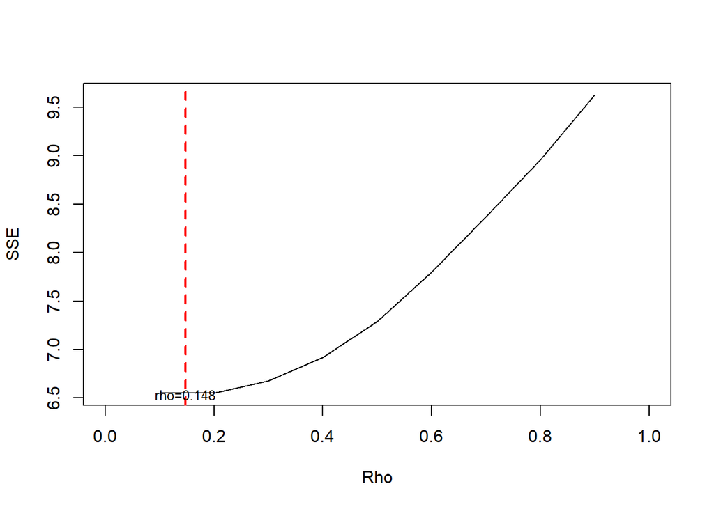

```r
#Grafik SSE optimum
par(mfrow = c(1,1))
plot(tab$SSE ~ tab$rho , type = "l", xlab = "Rho", xlim = c(0.00,1.00), ylab = "SSE")
abline(v = tabOpt[tabOpt$SSE==min(tabOpt$SSE),"rho"], lty = 2, col="red",lwd=2)
text(x=0.148, y=6.536743, labels = "rho=0.148", cex = 0.8)
```

```r
dev.copy(png, "Grafik SSE Optimum.png")
```

```r
dev.off()
```

Perhitungan yang dilakukan aplikasi `R` menunjukkan bahwa nilai $ρ$ optimum, yaitu saat SSE terkecil terdapat pada nilai $ρ=0.148$. Hal tersebut juga ditunjukkan pada plot. Selanjutnya, model dapat didapatkan dengan mengevaluasi nilai $ρ$ ke dalam fungsi `hildreth.lu.func`, serta dilanjutkan dengan pengujian autokorelasi dengan uji Durbin-Watson. Namun, setelah pengecekan tersebut tidak lupa koefisien regresi tersebut digunakan untuk transformasi balik. Persamaan hasil transformasi itulah yang menjadi persamaan sesungguhnya.

```r
#Model terbaik
modelHL <- hildreth.lu.func(0.148, model[])
summary(modelHL)
```

```
##
## Call:
## lm(formula = y ~ x1 + x2 + x3 + x4 + x5)
##
## Residuals:
##      Min       1Q   Median       3Q      Max
## -0.83883 -0.25468  0.03446  0.25317  0.54521
##
## Coefficients:
##             Estimate Std. Error t value Pr(>|t|)
## (Intercept) -3.59643    3.34221  -1.076  0.28588
## x1           0.01849    0.01940   0.953  0.34414
## x2           8.22537    5.88259   1.398  0.16679
## x3           0.46299    0.01435  32.268  < 2e-16 ***
## x4           1.02443    0.15585   6.573 9.78e-09 ***
## x5          -6.06966    2.12349  -2.858  0.00572 **
## ---
## Signif. codes:  0 '***' 0.001 '**' 0.01 '*' 0.05 '.' 0.1 ' ' 1
##
## Residual standard error: 0.3171 on 65 degrees of freedom
## Multiple R-squared:  0.9863, Adjusted R-squared:  0.9853
## F-statistic: 937.1 on 5 and 65 DF,  p-value: < 2.2e-16
```

```r
#Transformasi Balik
cat("y = ", coef(modelHL)[1]/(1-0.148), " + ", coef(modelHL)[2], "x1", " + ", coef(modelHL)[3], "x2", " + ", coef(modelHL)[4], "x3", " + ", coef(modelHL)[5], "x4 ",  coef(modelHL)[6],"x5", sep = "")
```

```
## y = -4.221165 + 0.01848717x1 + 8.225374x2 + 0.4629872x3 + 1.024426x4 -6.069655x5
```

Setelah dilakukan tranformasi balik, didapatkan model dengan metode Hildreth-Lu sebagai berikut.
$$y_{it}=-4.221165+0.01848717x_{1t}+8.225374x_{2t}+0.4629872x_{3t}+1.024426x_{4t}-6.069655x_{5t}$$

```r
#Deteksi autokorelasi
dwtest(modelHL)
```

```
##
##  Durbin-Watson test
##
## data:  modelHL
## DW = 2.1392, p-value = 0.5055
## alternative hypothesis: true autocorrelation is greater than 0
```

Terakhir, akan dibandingkan nilai SSE dari ketiga metode (metode awal, metode Cochrane-Orcutt, dan Hildreth-Lu).

```r
#Perbandingan
sseModelawal <- anova(model)$`Sum Sq`[6]
sseModelCO <- anova(modelCOmanual)$`Sum Sq`[6]
sseModelHL <- anova(modelHL)$`Sum Sq`[6]
mseModelawal <- sseModelawal/length(Y)
mseModelCO <- sseModelCO/length(Y)
mseModelHL <- sseModelHL/length(Y)
akurasi <- matrix(c(sseModelawal,sseModelCO,sseModelHL,
                    mseModelawal,mseModelCO,mseModelHL),nrow=2,ncol=3,byrow = T)
colnames(akurasi) <- c("Model Awal", "Model Cochrane-Orcutt", "Model Hildreth-Lu")
row.names(akurasi) <- c("SSE","MSE")
akurasi
```

```
##     Model Awal Model Cochrane-Orcutt Model Hildreth-Lu
## SSE 7.00358086            6.53674213        6.53674271
## MSE 0.09727196            0.09078809        0.09078809
```

Berdasarkan hasil tersebut dapat diketahui bahwa hasil penanganan autokorelasi dengan metode Cochrane-Orcutt dan Hildreth-Lu memiliki SSE yang sama, sebesar $6.536742$ dan lebih baik dibandingkan model awal ketika autokorelasi masih terjadi, yaitu sebesar $7.00358086$.

# Simpulan

Autokorelasi yang terdapat pada data Air Quality New-delhi terjadi akibat adanya korelasi di antara unsur penyusunnya. Indikator AQI yang erat hubungannya dengan peubah CO, NO2, O3, pm25, dan SO2 sangat rawan menjadi penyebab adanya autokorelasi. Adanya autokorelasi menyebabkan model regresi kurang baik karena akan meingkatkan galatnya. Autokorelasi dapat dideteksi secara eksploratif melalui plot sisaan, ACF, dan PACF, serta dengan uji formal Durbin-Watson. Namun, autokorelasi tersebut dapat ditangani dengan metode Cochrane-Orcutt dan Hildreth-Lu. Kedua metode menghasilkan nilai SSE yang sama, artinya keduanya baik untuk digunakan.